# epidemiologie

nadege

08/05/2021

# Plan de travail:

Travailler sur un jeu de données et développer un modèle qui permet de d’évaluer ou prédire la relation entre certains paramètres

## Jeux de données à disposition

```
## # A tibble: 11,088 x 8
##    plot  variety       irrigation          x     y     t     i     n
##    <fct> <fct>         <fct>           <int> <int> <int> <int> <int>
##  1 1A    Burwood-Prize overhead-sprays     1     1     1     0     1
##  2 1A    Burwood-Prize overhead-sprays     1     1     2     0     1
##  3 1A    Burwood-Prize overhead-sprays     1     1     3     1     1
##  4 1A    Burwood-Prize overhead-sprays     1     1     4     1     1
##  5 1A    Burwood-Prize overhead-sprays     1     1     5     1     1
##  6 1A    Burwood-Prize overhead-sprays     1     1     6     1     1
##  7 1A    Burwood-Prize overhead-sprays     1     2     1     0     1
##  8 1A    Burwood-Prize overhead-sprays     1     2     2     0     1
##  9 1A    Burwood-Prize overhead-sprays     1     2     3     1     1
## 10 1A    Burwood-Prize overhead-sprays     1     2     4     1     1
## # ... with 11,078 more rows
```

## Description des données

Ce jeu de données, récolté par Bald (1937) et distribué par le package R nommé epiphy de Christophe Gigot (2018), contient les données de 4 parcelles.

Les tomates furent plantées le 15 Octobre 1928.

Les 2 parcelles dédiées à chaque variété ont été soumises à des formes d’irrigations différentes, utilisant soit des rampes d’aspersion aériennes (“overhead-sprays”), soit des tranchées (“trenches”).

En dehors de celà elles ont reçu le même traitement.

Nous décrivons les différentes variables du jeu de données :

- plot : Identifiant de la parcelle
- variety : Nom de la variété
- irrigation : Système d’irrigation
- x,y : coordonnées spatiales
- t Semaine d’évaluation de la maladie (1: 6 Nov, 2: 14 Nov, 3: 21 Nov, 4: 28-29 Nov, 5: 5 Dec, 6: 12 Dec 1928.)
- i : Incidence de la maladie (0: sain, 1: malade)
- n : Unité d’échantillonage, toujours 1 ici donc ignoré

Compte des observations :

```
## # A tibble: 4 x 4
##   plot  variety         irrigation          n
##   <fct> <fct>           <fct>           <int>
## 1 1A    Burwood-Prize   overhead-sprays  2772
## 2 1B    Burwood-Prize   trenches         2772
## 3 2A    Early-Dwarf-Red trenches         2772
## 4 2B    Early-Dwarf-Red overhead-sprays  2772
```

## Feature engineering

En plus de ces données, nous créons 2 nouvelles variables, qui varient avec le temps, le nombre total de plantes malades dans la parcelle au moment de la mesure, et le nombre de plantes voisines malades au moment de la mesure.

```
## # A tibble: 11,088 x 9
##    plot  variety       irrigation          x     y     t     i total_diseased
##    <fct> <fct>         <fct>           <int> <int> <int> <int>          <int>
##  1 1A    Burwood-Prize overhead-sprays     1     1     1     0             36
##  2 1A    Burwood-Prize overhead-sprays     1     1     2     0            133
##  3 1A    Burwood-Prize overhead-sprays     1     1     3     1            231
##  4 1A    Burwood-Prize overhead-sprays     1     1     4     1            324
##  5 1A    Burwood-Prize overhead-sprays     1     1     5     1            377
##  6 1A    Burwood-Prize overhead-sprays     1     1     6     1            403
##  7 1A    Burwood-Prize overhead-sprays     1     2     1     0             36
##  8 1A    Burwood-Prize overhead-sprays     1     2     2     0            133
##  9 1A    Burwood-Prize overhead-sprays     1     2     3     1            231
## 10 1A    Burwood-Prize overhead-sprays     1     2     4     1            324
## # ... with 11,078 more rows, and 1 more variable: neighbours_diseased <int>
```

## Analyse des facteurs (paramètres,variables) qui ont été pris en compte

Nous allons observer l’influences des facteurs variety, irrigation, total_diseased et neighbours_diseased dans la progression de la maladie.

## Déterminer les relations pertinentes à faire entre les variables observées

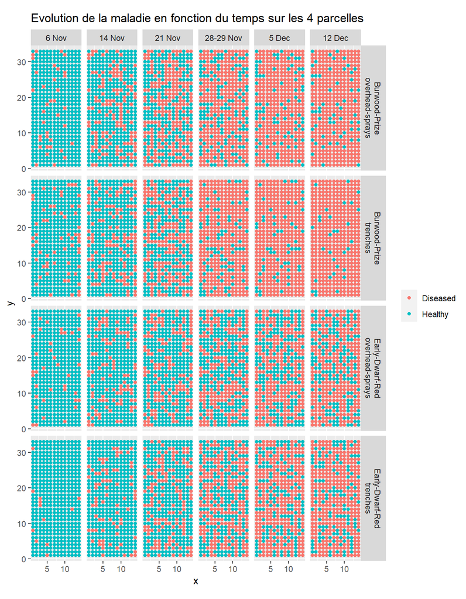

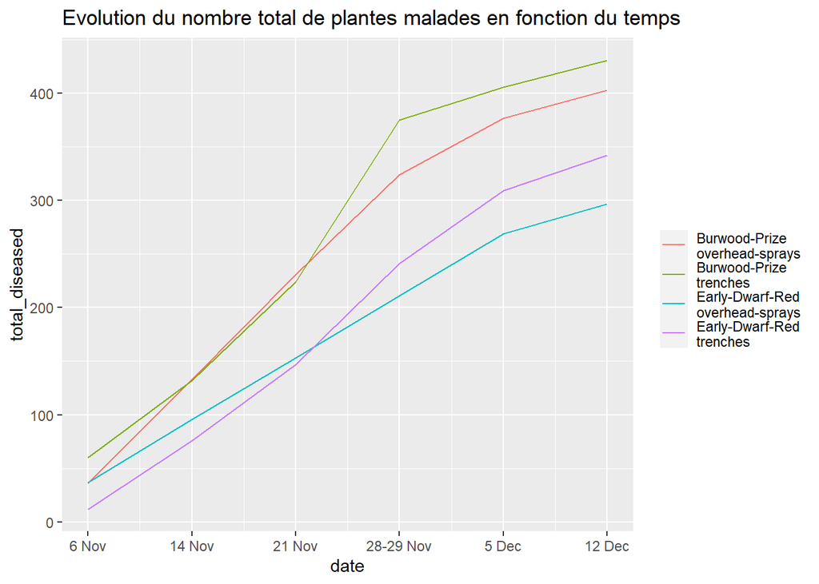